# 11. Duda: distribución agregada de oferta y demanda por nivel educativo

# 2. Metodología

## Librerías

```r
# paquetes ==========================================================
library(tidyverse)
# paleta de colores p. 422
library(RColorBrewer)
# letter value plot p. 99 (inglés)
library(lvplot)
# # calcular la moda
# library(DescTools)
# # coeficiente de asimetría
# library(moments)
# library(EnvStats)
library(modelr)
# análisis de residuos
library(performance)
library(car)
library(stats)
library(nortest)
library(moments)
library(lmtest)
library(see)
```

## Fuente de datos

```r
# importación =======================================================
# 3. sociodemográfica
sdem <- read_csv(
  "enoet22025/ENOE_SDEMT225.csv",
  col_types = cols(.default = col_character())
)

# 4. ocupación y empleo I
coe1 <- read_csv(
  "enoet22025/ENOE_COE1T225.csv",
  col_types = cols(.default = col_character())
)

# 5. ocupación y empleo II
coe2 <- read_csv(
  "enoet22025/ENOE_COE2T225.csv",
  col_types = cols(.default = col_character())
)
```

## Segmentación

```r
# segmentación ======================================================
sdem<- sdem %>% mutate(
  # edad
  edad = as.integer(eda),
  # años de estudios
  anios_estudios = as.integer(anios_esc),
  # 99 pasa a NA para evitar 99 - edu_req
  anios_estudios = if_else(anios_estudios != 99, anios_estudios, NA),
  # grado escolar
  escolaridad = as.integer(cs_p13_1),
  # 99 pasa a NA para evitar 99 - edu_req
  escolaridad = if_else(escolaridad != 99, escolaridad, NA),
  # ponderador trimestral
  fac_tri = as.double(fac_tri),
  # ingreso mensual
  ingreso_mensual = as.double(ingocup),
  # 0 pasa a NA ya que 0==NA en p6b2
  ingreso_mensual = if_else(ingreso_mensual != 0, ingreso_mensual, NA),
  # promedio de ingreso por hora
  ingreso_hora = as.double(ing_x_hrs),
  # 0 pasa a NA ya que 0==NA en p6b2 y en dur9c == 1 & 9
  ingreso_hora = if_else(ingreso_hora != 0, ingreso_hora, NA)
)
```

## Construcción de variables

```r
# construcción de variables =========================================
# grupos de edadd OECD(2019: 135)
sdem <- sdem %>%
  mutate(
    edad_7g = case_when(
      between(edad, 0, 14) ~ "1",
      between(edad, 15, 24) ~ "2",
      between(edad, 25, 34) ~ "3",
      between(edad, 35, 44) ~ "4",
      between(edad, 45, 54) ~ "5",
      between(edad, 55, 64) ~ "6",
      between(edad, 65, 97) ~ "7",
      # edad no especificada mayores a 12 INEGI(2024:16)
      edad == "98" ~ "98",
      # edad no especificada menores a 12 INEGI(2024:16)
      edad == "99" ~ "99",
      # NA sin comillas para valores faltantes
      TRUE ~ NA
    )
  )

# carreras universitaria INEGI(2016: 13)
sdem <- sdem %>%
  mutate(
    carrera1 = if_else(str_length(cs_p14_c) == 5, str_c("0", cs_p14_c), cs_p14_c),
    carrera2 = if_else(str_length(cs_p14_c) == 5, str_c("0", cs_p14_c), cs_p14_c),
    carrera3 = if_else(str_length(cs_p14_c) == 5, str_c("0", cs_p14_c), cs_p14_c)
  ) %>%
  separate(
    carrera1,
    # campo amplio
    into = c("carrera1", "res"),
    sep = 2
  ) %>%
  separate(
    carrera2,
    # campo específico
    into = c("carrera2", "res"),
    sep = 3
  ) %>%
  separate(
    carrera3,
    # campo detallado
    into = c("carrera3", "res"),
    sep = 4
  ) %>%
  select(-res)

# grupos ocupacionales INEGI(2019: 22)
coe1 <- coe1 %>%
  mutate(
    ocupacion1 = p3,
    ocupacion2 = p3,
    ocupacion3 = p3
  ) %>%
  separate(
    ocupacion1,
    into = c("ocupacion1", "res"),
    sep = 1
  ) %>%
  separate(
    ocupacion2,
    into = c("ocupacion2", "res"),
    sep = 2
  ) %>%
  separate(
    ocupacion3,
    into = c("ocupacion3", "res"),
    sep = 3
  ) %>%
  select(-res)
```

## Creación de tablas

```r
# creación de tablas ================================================
# población de 12 y más para unir sdem y coe INEGI(2023:9)
pob_12ymas <- sdem %>%
  filter(
  r_def == "0",
  c_res != "2",
  between(edad, 12, 98)
  )

# nrow(pob_12ymas)
# nrow(coe1)

# población total INEGI(2023:21)
pob_total <- sdem %>%
  filter(
    r_def == "0",
    # es igual a (c_res == "1" | c_res == "3")
    c_res != "2"
  )

# población de 12 y más para unir sdem y coe INEGI(2023:9)
pob_12ymas <- sdem %>%
  filter(
  r_def == "0",
  c_res != "2",
  between(edad, 12, 98)
  )

# unión de sdem y coe INEGI(2023:9)
completo <- pob_12ymas %>%
  full_join(coe1, by = c("tipo", "mes_cal", "cd_a", "ent", "con", "v_sel", "n_hog", "h_mud", "n_ren")) %>%
  full_join(coe2, by = c("tipo", "mes_cal", "cd_a", "ent", "con", "v_sel", "n_hog", "h_mud", "n_ren"))

# población de 15 años y más INEGI(2023:21)
pob_15ymas <- completo %>%
  filter(
    r_def.x == "0",
    c_res != "2",
    between(edad, 15, 98)
  )

# INEGI(2023: 21)
ocupada <- pob_15ymas %>%
  filter(clase2 == 1)

# INEGI(2023: 25)
desocupada <- pob_15ymas %>%
  filter(clase2 == 2)

# INEGI(2023: 26)
pnea <- pob_15ymas %>%
  filter(clase1 == 2)
```

## Incidencia

### Método objetivo

```r
# método: objetivo --------------------------------------------------
# con el grupo división INEGI(2020: 22)
educacion_req_objetivo <- ocupada %>%
  count(ocupacion1) %>%
  mutate(
    objetivo_min = case_when(
      ocupacion1 == 1 ~ 5,
      ocupacion1 == 2 ~ 5,
      ocupacion1 == 3 ~ 3,
      ocupacion1 == 4 ~ 3,
      ocupacion1 == 5 ~ 3,
      ocupacion1 == 6 ~ 3,
      ocupacion1 == 7 ~ 3,
      ocupacion1 == 8 ~ 3,
      ocupacion1 == 9 ~ 2,
      TRUE ~ NA
    ),
    objetivo_max = case_when(
      ocupacion1 == 1 ~ 9,
      ocupacion1 == 2 ~ 9,
      ocupacion1 == 3 ~ 4,
      ocupacion1 == 4 ~ 4,
      ocupacion1 == 5 ~ 4,
      ocupacion1 == 6 ~ 4,
      ocupacion1 == 7 ~ 4,
      ocupacion1 == 8 ~ 4,
      ocupacion1 == 9 ~ 2,
      TRUE ~ NA
    )
    # objetivo_min = as.integer(objetivo_min),
    # objetivo_max = as.integer(objetivo_max)
  ) %>%
  select(-n)

# comprobación
# educacion_req_objetivo
```

### Método estadístico

```r
# método: verdugo ---------------------------------------------------
# con el subgrupo INEGI(2020: 22)

educacion_req_verdugo <- ocupada %>%
  filter(!is.na(anios_estudios)) %>%
  group_by(ocupacion3) %>%
  summarise(
    verdugo_neg = mean(anios_estudios) - sd(anios_estudios),
    verdugo_media = mean(anios_estudios),
    verdugo_pos = mean(anios_estudios) + sd(anios_estudios)
  )

# método: mediana ---------------------------------------------------
# con el subgrupo INEGI(2020: 22)
educacion_req_mediana <- ocupada %>%
  filter(!is.na(anios_estudios)) %>%
  group_by(ocupacion3) %>%
  summarise(
    mediana = median(anios_estudios)
  )

# método: moda ------------------------------------------------------
# con el subgrupo INEGI(2020: 22)
educacion_req_moda <- ocupada %>%
  filter(!is.na(anios_estudios)) %>%
  group_by(ocupacion3, anios_estudios) %>%
  summarise(
    tot = sum(n())
  ) %>%
    filter(tot == max(tot)) %>%
    rename("moda" = "anios_estudios") %>%
    select(-tot)
# comprobación
educacion_req_verdugo
```

```
## # A tibble: 163 × 4
##    ocupacion3 verdugo_neg verdugo_media verdugo_pos
##    <chr>            <dbl>         <dbl>       <dbl>
##  1 111               9.41          13.6        17.8
##  2 112              13.6           15.9        18.2
##  3 113               8.74          12.8        16.8
##  4 121              13.5           15.8        18.1
##  5 122              14.6           16.8        18.9
##  6 131              11.8           15.0        18.2
##  7 132              11.8           15.0        18.2
##  8 141              11.3           14.3        17.4
##  9 142              11.0           14.3        17.7
## 10 151              12.1           15.0        17.9
## # ℹ 153 more rows
```

```r
educacion_req_moda
```

```
## # A tibble: 179 × 2
## # Groups:   ocupacion3 [163]
##    ocupacion3  moda
##    <chr>      <int>
##  1 111           16
##  2 112           17
##  3 113           12
##  4 121           16
##  5 122           16
##  6 131           17
##  7 132           16
##  8 132           17
##  9 141           17
## 10 142           17
## # ℹ 169 more rows
```

```r
educacion_req_mediana
```

```
## # A tibble: 163 × 2
##    ocupacion3 mediana
##    <chr>        <dbl>
##  1 111             16
##  2 112             16
##  3 113             12
##  4 121             16
##  5 122             17
##  6 131             16
##  7 132             16
##  8 141             16
##  9 142             16
## 10 151             16
## # ℹ 153 more rows
```

Se intentarán añadir las modas adicionales.

```r
# original
df <- educacion_req_moda %>%
  mutate(valid = (ocupacion3 == lag(ocupacion3)))

# 163
moda1 <- df %>%
  filter(is.na(valid)) %>%
  rename("moda1" = "moda")

df <- df %>%
  filter(!is.na(valid)) %>%
  mutate(valid = (ocupacion3 == lag(ocupacion3)))

# 13
moda2 <- df %>%
  filter(is.na(valid)) %>%
  rename("moda2" = "moda")

df <- df %>%
  filter(!is.na(valid)) %>%
  mutate(valid = (ocupacion3 == lag(ocupacion3)))

# 2
moda3 <- df %>%
  filter(is.na(valid)) %>%
  rename("moda3" = "moda")

# 1
moda4 <- df %>%
  filter(!is.na(valid)) %>%
  rename("moda4" = "moda")

educacion_req_moda <- moda1 %>%
  left_join(moda2, by = "ocupacion3") %>%
  left_join(moda3, by = "ocupacion3") %>%
  left_join(moda4, by = "ocupacion3") %>%
  select(-contains("valid"))
```

### Determinación de la incidencia

#### Objetivo

```r
# desajuste educativo con el método objetivo
objetivo <- ocupada %>% left_join(educacion_req_objetivo, by = "ocupacion1") %>%
  mutate(
    desajuste_educativo = case_when(
      # required
      between(escolaridad, objetivo_min, objetivo_max) ~ 0,
      # over
      escolaridad > objetivo_max ~ 1,
      # under
      escolaridad < objetivo_min ~ 2,
      TRUE ~ NA
    ),
    # variables binarias
    over_obj = if_else(escolaridad > objetivo_max, 1, 0),
    required_obj = if_else(between(escolaridad, objetivo_min, objetivo_max), 1, 0),
    under_obj = if_else(escolaridad < objetivo_max, 1, 0)
    # variables de años de sobre o infra
    # objetivo: no se puede obtener ya que son grados y están en intervalos
  )
```

#### Estadístico

Verdugo

```r
# variable de desajuste educativo con método verdugo
verdugo <- ocupada %>% left_join(educacion_req_verdugo, by = "ocupacion3") %>%
  mutate(
    # verdugo y verdugo
    desajuste_educativo = case_when(
      # required
      between(anios_estudios, verdugo_neg, verdugo_pos) ~ 0,
      # over
      anios_estudios > verdugo_pos ~ 1,
      # under
      anios_estudios < verdugo_neg ~ 2,
      TRUE ~ NA
    ),
    # variables binarias
    over_vv = if_else(anios_estudios > verdugo_pos, 1, 0),
    required_vv = if_else(between(anios_estudios, verdugo_neg, verdugo_pos), 1, 0),
    under_vv = if_else(anios_estudios < verdugo_neg, 1, 0)
  )
```

Moda

```r
# variable de desajuste educativo con método moda
moda <- ocupada %>% left_join(educacion_req_moda , by = "ocupacion3") %>%
  mutate(
    # moda
    desajuste_educativo = case_when(
      # required
      !is.na(moda4) & between(anios_estudios, moda1, moda4) | !is.na(moda3) & between(anios_estudios, moda1, moda3) | !is.na(moda2) & between(anios_estudios, moda1, moda2) | anios_estudios == moda1 ~ 0,
      # over
      (!is.na(moda4) & anios_estudios > moda4) | (!is.na(moda3) & anios_estudios > moda3) | (!is.na(moda2) & anios_estudios > moda2) | (anios_estudios > moda1) ~ 1,
      # under
      anios_estudios < moda1 ~ 2,
      TRUE ~ NA
    ),
    # variables binarias
    over_moda = if_else(desajuste_educativo == 1, 1, 0),
    required_moda = if_else(desajuste_educativo == 0, 1, 0),
    under_moda = if_else(desajuste_educativo == 2, 1, 0)
  )
```

Cabe señalar que en los casos donde hay más de una moda, se estableció un intervalo como educación requerida donde el valor mínimo corresponde a `moda1` y el valor máximo a `moda4`. En casos contrarios, se establece con `moda1`.

Mediana

```r
# variable de desajuste educativo con método mediana
mediana <- ocupada %>% left_join(educacion_req_mediana, by = "ocupacion3") %>%
  mutate(
    # mediana
    desajuste_educativo = case_when(
      # required
      anios_estudios == mediana ~ 0,
      # over
      anios_estudios > mediana ~ 1,
      # under
      anios_estudios < mediana ~ 2,
      TRUE ~ NA
    ),
    # variables binarias
    over_mediana = if_else(anios_estudios > mediana, 1, 0),
    required_mediana = if_else(anios_estudios == mediana, 1, 0),
    under_mediana = if_else(anios_estudios < mediana, 1, 0),
    # variables de años de desajuste
    so_mediana = if_else(anios_estudios > mediana, anios_estudios - mediana, 0),
    sr_mediana = if_else(anios_estudios == mediana, anios_estudios, 0),
    su_mediana = if_else(anios_estudios < mediana, mediana - anios_estudios , 0)
  )
```

### Efecto salarial

#### Construcción de las demás variables explicativas

```r
# otras variables explicativas ======================================

# objetivo ------------------------------------------------
objetivo <- objetivo %>%
  mutate(
    # horas trabajadas
    # 999 indica no específicado, se convierte a NA INEGI(2024:81)
    horas_lab = if_else(p5b_thrs != 999, p5b_thrs, NA),
    horas_lab = as.double(horas_lab),
    # experiencia laboral potencial
    # si es <= 0, se convierte a NA; no afecta al grupo de jóvenes
    # si edad == 98, se convierte a NA
    # experiencia = edadd - años estudios - 6
    # Zamudio e Islas(1999) y Mincer(1974)
    exper = edad - anios_estudios - 6,
    exper = if_else(exper > 0 & edad != 98, exper, NA),
    # experiencia ^ 2 para que el ingreso tenga una forma de U
    exper2 = exper ** 2,
    # género == 1 si es hombre
    hombre = if_else(sex == 1, 1, 0),
    # estado civil == 1 si es casadao
    casada = if_else(e_con == 5, 1, 0),
    # situación de hogar == 1 si es jefe INEGI(2020:37)
    jefe_hogar = if_else(par_c == 101, 1, 0),
    # variables dicotómicas para los grupos ocupacionales
    # grupo de referencia: 9 INEGI(2020: 27)
    func_dir_jefes = if_else(ocupacion1 == 1, 1, 0),
    prof_tecnicos = if_else(ocupacion1 == 2, 1, 0),
    aux_admin = if_else(ocupacion1 == 3, 1, 0),
    comerc_ventas = if_else(ocupacion1 == 4, 1, 0),
    serv_vig = if_else(ocupacion1 == 5, 1, 0),
    agric_gan_for = if_else(ocupacion1 == 6, 1, 0),
    art_constr = if_else(ocupacion1 == 7, 1, 0),
    maq_ens = if_else(ocupacion1 == 8, 1, 0),
    elementales = if_else(ocupacion1 == 9, 1, 0)
  )

# verdugo -------------------------------------------------
verdugo <- verdugo %>%
  mutate(
    # horas trabajadas
    # 999 indica no específicado, se convierte a NA INEGI(2024:81)
    horas_lab = if_else(p5b_thrs != 999, p5b_thrs, NA),
    horas_lab = as.double(horas_lab),
    # experiencia laboral potencial
    # si es <= 0, se convierte a NA; no afecta al grupo de jóvenes
    # si edad == 98, se convierte a NA
    # experiencia = edadd - años estudios - 6
    # Zamudio e Islas(1999) y Mincer(1974)
    exper = edad - anios_estudios - 6,
    exper = if_else(exper > 0 & edad != 98, exper, NA),
    # experiencia ^ 2 para que el ingreso tenga una forma de U
    exper2 = exper ** 2,
    # género == 1 si es hombre
    hombre = if_else(sex == 1, 1, 0),
    # estado civil == 1 si es casadao
    casada = if_else(e_con == 5, 1, 0),
    # situación de hogar == 1 si es jefe INEGI(2020:37)
    jefe_hogar = if_else(par_c == 101, 1, 0),
    # variables dicotómicas para los grupos ocupacionales
    # grupo de referencia: 9 INEGI(2020: 27)
    func_dir_jefes = if_else(ocupacion1 == 1, 1, 0),
    prof_tecnicos = if_else(ocupacion1 == 2, 1, 0),
    aux_admin = if_else(ocupacion1 == 3, 1, 0),
    comerc_ventas = if_else(ocupacion1 == 4, 1, 0),
    serv_vig = if_else(ocupacion1 == 5, 1, 0),
    agric_gan_for = if_else(ocupacion1 == 6, 1, 0),
    art_constr = if_else(ocupacion1 == 7, 1, 0),
    maq_ens = if_else(ocupacion1 == 8, 1, 0),
    elementales = if_else(ocupacion1 == 9, 1, 0)
  )

# moda ----------------------------------------------------
moda <- moda %>%
  mutate(
    # horas trabajadas
    # 999 indica no específicado, se convierte a NA INEGI(2024:81)
    horas_lab = if_else(p5b_thrs != 999, p5b_thrs, NA),
    horas_lab = as.double(horas_lab),
    # experiencia laboral potencial
    # si es <= 0, se convierte a NA; no afecta al grupo de jóvenes
    # si edad == 98, se convierte a NA
    # experiencia = edadd - años estudios - 6
    # Zamudio e Islas(1999) y Mincer(1974)
    exper = edad - anios_estudios - 6,
    exper = if_else(exper > 0 & edad != 98, exper, NA),
    # experiencia ^ 2 para que el ingreso tenga una forma de U
    exper2 = exper ** 2,
    # género == 1 si es hombre
    hombre = if_else(sex == 1, 1, 0),
    # estado civil == 1 si es casadao
    casada = if_else(e_con == 5, 1, 0),
    # situación de hogar == 1 si es jefe INEGI(2020:37)
    jefe_hogar = if_else(par_c == 101, 1, 0),
    # variables dicotómicas para los grupos ocupacionales
    # grupo de referencia: 9 INEGI(2020: 27)
    func_dir_jefes = if_else(ocupacion1 == 1, 1, 0),
    prof_tecnicos = if_else(ocupacion1 == 2, 1, 0),
    aux_admin = if_else(ocupacion1 == 3, 1, 0),
    comerc_ventas = if_else(ocupacion1 == 4, 1, 0),
    serv_vig = if_else(ocupacion1 == 5, 1, 0),
    agric_gan_for = if_else(ocupacion1 == 6, 1, 0),
    art_constr = if_else(ocupacion1 == 7, 1, 0),
    maq_ens = if_else(ocupacion1 == 8, 1, 0),
    elementales = if_else(ocupacion1 == 9, 1, 0)
  )

# mediana -------------------------------------------------
mediana <- mediana %>%
  mutate(
    # horas trabajadas
    # 999 indica no específicado, se convierte a NA INEGI(2024:81)
    horas_lab = if_else(p5b_thrs != 999, p5b_thrs, NA),
    horas_lab = as.double(horas_lab),
    # experiencia laboral potencial
    # si es <= 0, se convierte a NA; no afecta al grupo de jóvenes
    # si edad == 98, se convierte a NA
    # experiencia = edadd - años estudios - 6
    # Zamudio e Islas(1999) y Mincer(1974)
    exper = edad - anios_estudios - 6,
    exper = if_else(exper > 0 & edad != 98, exper, NA),
    # experiencia ^ 2 para que el ingreso tenga una forma de U
    exper2 = exper ** 2,
    # género == 1 si es hombre
    hombre = if_else(sex == 1, 1, 0),
    # estado civil == 1 si es casadao
    casada = if_else(e_con == 5, 1, 0),
    # situación de hogar == 1 si es jefe INEGI(2020:37)
    jefe_hogar = if_else(par_c == 101, 1, 0),
    # variables dicotómicas para los grupos ocupacionales
    # grupo de referencia: 9 INEGI(2020: 27)
    func_dir_jefes = if_else(ocupacion1 == 1, 1, 0),
    prof_tecnicos = if_else(ocupacion1 == 2, 1, 0),
    aux_admin = if_else(ocupacion1 == 3, 1, 0),
    comerc_ventas = if_else(ocupacion1 == 4, 1, 0),
    serv_vig = if_else(ocupacion1 == 5, 1, 0),
    agric_gan_for = if_else(ocupacion1 == 6, 1, 0),
    art_constr = if_else(ocupacion1 == 7, 1, 0),
    maq_ens = if_else(ocupacion1 == 8, 1, 0),
    elementales = if_else(ocupacion1 == 9, 1, 0)
  )
```

## Tabla de jóvenes profesionistas

```r
# Se considera licenciatura, maestría y doctorado

# objetivo ------------------------------------------------
jov_prof_obj <- objetivo %>%
  mutate(escolaridad = as.integer(cs_p13_1)) %>%
  filter(between(escolaridad, 7, 9) & edad_7g == 3)

# verdugo -------------------------------------------------
jov_prof_vv <- verdugo %>%
  mutate(escolaridad = as.integer(cs_p13_1)) %>%
  filter(between(escolaridad, 7, 9) & edad_7g == 3)

# moda ----------------------------------------------------
jov_prof_moda <- moda %>%
  mutate(escolaridad = as.integer(cs_p13_1)) %>%
  filter(between(escolaridad, 7, 9) & edad_7g == 3)

# mediana -------------------------------------------------
jov_prof_mediana <- mediana %>%
  mutate(escolaridad = as.integer(cs_p13_1)) %>%
  filter(between(escolaridad, 7, 9) & edad_7g == 3)
```

## Tamaño de las tablas

| Tabla | Tamaño |
| --- | --- |
| `SDEM` | 423,744 x 123 |
| `pob_total` | 413,004 x 123 |
| `pob_12ymas` | 346,404 x 123 |
| `COE1` | 346,404 x 175 |
| `COE2` | 346,404 x 82 |
| `completo` | 346,404 x 362 |
| `pob_15ymas` | 324,613 x 362 |
| `ocupada` | 190,687 x 362 |
| `pnea` | 128,643 x 362 |
| `desocupada` | 5,283 x 362 |
| `educacion_req_objetivo` | 9 x 3 |
| `educacion_req_verdugo` | 163 x 4 |
| `educacion_req_moda` | 163 x 5 |
| `educacion_req_mediana` | 163 x 2 |
| `objetivo` | 190,687 x 383 |
| `verdugo` | 190,687 x 384 |
| `moda` | 190,687 x 385 |
| `mediana` | 190,687 x 385 |
| `jov_prof_obj` | 17,485 x 383 |
| `jov_prof_vv` | 17,485 x 384 |
| `jov_prof_moda` | 17,485 x 385 |
| `jov_prof_moda` | 17,485 x 385 |

Fuente: elaboración propia con datos de ENOE 2T-25 (INEGI)

# 3. Resultados

## Ingreso mensual promedio

### General

```r
ingreso_obj <- objetivo %>%
  filter(!is.na(ingreso_mensual)) %>%
  group_by(desajuste_educativo) %>%
  summarise(objetivo = mean(ingreso_mensual))

ingreso_vv <- verdugo %>%
  filter(!is.na(ingreso_mensual)) %>%
  group_by(desajuste_educativo) %>%
  summarise(verdugo = mean(ingreso_mensual))

ingreso_moda <- moda %>%
  filter(!is.na(ingreso_mensual)) %>%
  group_by(desajuste_educativo) %>%
  summarise(moda = mean(ingreso_mensual))

ingreso_mediana <- mediana %>%
  filter(!is.na(ingreso_mensual)) %>%
  group_by(desajuste_educativo) %>%
  summarise(mediana = mean(ingreso_mensual))

ingreso_promedio <- ingreso_obj %>%
  full_join(ingreso_vv, by = "desajuste_educativo") %>%
  full_join(ingreso_moda, by = "desajuste_educativo") %>%
  full_join(ingreso_mediana, by = "desajuste_educativo")

ingreso_promedio
```

```
## # A tibble: 4 × 5
##   desajuste_educativo objetivo verdugo   moda mediana
##                 <dbl>    <dbl>   <dbl>  <dbl>   <dbl>
## 1                   0   11563.  10729. 10807.  10749.
## 2                   1    9611.  12536. 11834.  11908.
## 3                   2    9502.   8855.  9336.   9456.
## 4                  NA    9903.  10442. 10485.  10485.
```

### Jóvenes profesionistas

```r
ingreso_obj <- jov_prof_obj %>%
  filter(!is.na(ingreso_mensual)) %>%
  group_by(desajuste_educativo) %>%
  summarise(objetivo = mean(ingreso_mensual))

ingreso_vv <- jov_prof_vv %>%
  filter(!is.na(ingreso_mensual)) %>%
  group_by(desajuste_educativo) %>%
  summarise(verdugo = mean(ingreso_mensual))

ingreso_moda <- jov_prof_moda %>%
  filter(!is.na(ingreso_mensual)) %>%
  group_by(desajuste_educativo) %>%
  summarise(moda = mean(ingreso_mensual))

ingreso_mediana <- jov_prof_mediana %>%
  filter(!is.na(ingreso_mensual)) %>%
  group_by(desajuste_educativo) %>%
  summarise(mediana = mean(ingreso_mensual))

ingreso_promedio <- ingreso_obj %>%
  full_join(ingreso_vv, by = "desajuste_educativo") %>%
  full_join(ingreso_moda, by = "desajuste_educativo") %>%
  full_join(ingreso_mediana, by = "desajuste_educativo")

ingreso_promedio
```

```
## # A tibble: 4 × 5
##   desajuste_educativo objetivo verdugo   moda mediana
##                 <dbl>    <dbl>   <dbl>  <dbl>   <dbl>
## 1                   0   16417.  15503. 16963.  16109.
## 2                   1   12056.  12679. 13149.  13309.
## 3                   2      NA   16411. 17451.  16464.
## 4                  NA      NA    9764.  9764.   9764.
```

## Incidencia

### General

```r
incidencia_obj <- objetivo %>%
  count(desajuste_educativo) %>%
  mutate(prop_obj = n / sum(n)) %>%
  rename("objetivo" = "n")

incidencia_vv <- verdugo %>%
  count(desajuste_educativo) %>%
  mutate(prop_vv = n / sum(n)) %>%
  rename("verdugo" = "n")

incidencia_moda <- moda %>%
  count(desajuste_educativo) %>%
  mutate(prop_moda = n / sum(n)) %>%
  rename("moda" = "n")

incidencia_mediana <- mediana %>%
  count(desajuste_educativo) %>%
  mutate(prop_mediana = n / sum(n)) %>%
  rename("mediana" = "n")

incidencia <- incidencia_obj %>%
  full_join(incidencia_vv, by = "desajuste_educativo") %>%
  full_join(incidencia_moda, by = "desajuste_educativo") %>%
  full_join(incidencia_mediana, by = "desajuste_educativo")

incidencia
```

```
## # A tibble: 4 × 9
##   desajuste_educativo objetivo prop_obj verdugo prop_vv  moda prop_moda mediana
##                 <dbl>    <int>    <dbl>   <int>   <dbl> <int>     <dbl>   <int>
## 1                   0   106832  0.560    138731 0.728   65446   0.343     61790
## 2                   1    50004  0.262     24946 0.131   66004   0.346     64396
## 3                   2    33488  0.176     26475 0.139   58703   0.308     63967
## 4                  NA      363  0.00190     535 0.00281   534   0.00280     534
## # ℹ 1 more variable: prop_mediana <dbl>
```

### Jóvenes profesionistas

Agregado

```r
incidencia_obj <- jov_prof_obj %>%
  group_by(desajuste_educativo) %>%
  summarise(n = n()) %>%
  mutate(prop_obj = n / sum(n)) %>%
  rename("objetivo" = "n")

incidencia_vv <- jov_prof_vv %>%
  group_by(desajuste_educativo) %>%
  summarise(n = n()) %>%
  mutate(prop_vv = n / sum(n)) %>%
  rename("verdugo" = "n")

incidencia_moda <- jov_prof_moda %>%
  group_by(desajuste_educativo) %>%
  summarise(n = n()) %>%
  mutate(prop_moda = n / sum(n)) %>%
  rename("moda" = "n")

incidencia_mediana <- jov_prof_mediana %>%
  group_by(desajuste_educativo) %>%
  summarise(n = n()) %>%
  mutate(prop_mediana = n / sum(n)) %>%
  rename("mediana" = "n")

incidencia <- incidencia_obj %>%
  full_join(incidencia_vv, by = "desajuste_educativo") %>%
  full_join(incidencia_moda, by = "desajuste_educativo") %>%
  full_join(incidencia_mediana, by = "desajuste_educativo")

incidencia
```

```
## # A tibble: 4 × 9
##   desajuste_educativo objetivo prop_obj verdugo prop_vv  moda prop_moda mediana
##                 <dbl>    <int>    <dbl>   <int>   <dbl> <int>     <dbl>   <int>
## 1                   0     9475    0.542   10178 0.582    3678   0.210      4404
## 2                   1     8010    0.458    6915 0.395   11759   0.673     10759
## 3                   2       NA   NA         348 0.0199   2004   0.115      2278
## 4                  NA       NA   NA          44 0.00252    44   0.00252      44
## # ℹ 1 more variable: prop_mediana <dbl>
```

## Efecto salarial

### Jóvenes profesionistas

#### Modelo Verdugo

Objetivo

```r
# prof_tecnicos, required_obj y under _obj no significativos
modelo_obj <- lm(log(ingreso_mensual) ~ anios_estudios + over_obj + exper + exper2 + log(horas_lab) + hombre + casada + jefe_hogar + func_dir_jefes + aux_admin + comerc_ventas + serv_vig + agric_gan_for + art_constr + maq_ens, data = jov_prof_obj)

summary.lm(modelo_obj)
```

```
##
## Call:
## lm(formula = log(ingreso_mensual) ~ anios_estudios + over_obj +
##     exper + exper2 + log(horas_lab) + hombre + casada + jefe_hogar +
##     func_dir_jefes + aux_admin + comerc_ventas + serv_vig + agric_gan_for +
##     art_constr + maq_ens, data = jov_prof_obj)
##
## Residuals:
##     Min      1Q  Median      3Q     Max
## -3.8607 -0.3234 -0.0141  0.3148  2.5995
##
## Coefficients:
##                 Estimate Std. Error t value Pr(>|t|)
## (Intercept)     6.623263   0.104180  63.575  < 2e-16 ***
## anios_estudios  0.054139   0.005411  10.004  < 2e-16 ***
## over_obj       -0.526574   0.026695 -19.725  < 2e-16 ***
## exper           0.055422   0.009231   6.004 2.00e-09 ***
## exper2         -0.002775   0.000618  -4.491 7.18e-06 ***
## log(horas_lab)  0.455602   0.011721  38.869  < 2e-16 ***
## hombre          0.109229   0.012250   8.916  < 2e-16 ***
## casada          0.064931   0.013502   4.809 1.54e-06 ***
## jefe_hogar      0.168262   0.012999  12.944  < 2e-16 ***
## func_dir_jefes  0.180467   0.023455   7.694 1.57e-14 ***
## aux_admin       0.321446   0.029426  10.924  < 2e-16 ***
## comerc_ventas   0.176474   0.030176   5.848 5.14e-09 ***
## serv_vig        0.182817   0.033259   5.497 3.97e-08 ***
## agric_gan_for   0.216949   0.068722   3.157   0.0016 **
## art_constr      0.164146   0.037695   4.355 1.35e-05 ***
## maq_ens         0.295287   0.033188   8.898  < 2e-16 ***
## ---
## Signif. codes:  0 '***' 0.001 '**' 0.01 '*' 0.05 '.' 0.1 ' ' 1
##
## Residual standard error: 0.539 on 9133 degrees of freedom
##   (8336 observations deleted due to missingness)
## Multiple R-squared:  0.2917, Adjusted R-squared:  0.2905
## F-statistic: 250.7 on 15 and 9133 DF,  p-value: < 2.2e-16
```

Verdugo

```r
# required_obj y under _obj no significativos
modelo_vv <- lm(log(ingreso_mensual) ~ anios_estudios + over_vv + exper + exper2 + log(horas_lab) + hombre + casada + jefe_hogar + func_dir_jefes + prof_tecnicos + aux_admin + comerc_ventas + serv_vig + agric_gan_for + art_constr + maq_ens, data = jov_prof_vv)

summary.lm(modelo_vv)
```

```
##
## Call:
## lm(formula = log(ingreso_mensual) ~ anios_estudios + over_vv +
##     exper + exper2 + log(horas_lab) + hombre + casada + jefe_hogar +
##     func_dir_jefes + prof_tecnicos + aux_admin + comerc_ventas +
##     serv_vig + agric_gan_for + art_constr + maq_ens, data = jov_prof_vv)
##
## Residuals:
##     Min      1Q  Median      3Q     Max
## -3.8980 -0.3185 -0.0148  0.3130  2.5798
##
## Coefficients:
##                  Estimate Std. Error t value Pr(>|t|)
## (Intercept)     5.9475184  0.1043212  57.012  < 2e-16 ***
## anios_estudios  0.0720439  0.0057457  12.539  < 2e-16 ***
## over_vv        -0.1428604  0.0159208  -8.973  < 2e-16 ***
## exper           0.0557716  0.0091910   6.068 1.35e-09 ***
## exper2         -0.0028313  0.0006153  -4.601 4.26e-06 ***
## log(horas_lab)  0.4550954  0.0116709  38.994  < 2e-16 ***
## hombre          0.1181509  0.0122378   9.655  < 2e-16 ***
## casada          0.0636412  0.0134445   4.734 2.24e-06 ***
## jefe_hogar      0.1699207  0.0129440  13.127  < 2e-16 ***
## func_dir_jefes  0.5786232  0.0362500  15.962  < 2e-16 ***
## prof_tecnicos   0.4011375  0.0300317  13.357  < 2e-16 ***
## aux_admin       0.2288514  0.0310629   7.367 1.89e-13 ***
## comerc_ventas   0.1461684  0.0302352   4.834 1.36e-06 ***
## serv_vig        0.1707744  0.0331423   5.153 2.62e-07 ***
## agric_gan_for   0.2091611  0.0684304   3.057 0.002245 **
## art_constr      0.1411018  0.0376194   3.751 0.000177 ***
## maq_ens         0.2839943  0.0330680   8.588  < 2e-16 ***
## ---
## Signif. codes:  0 '***' 0.001 '**' 0.01 '*' 0.05 '.' 0.1 ' ' 1
##
## Residual standard error: 0.5366 on 9132 degrees of freedom
##   (8336 observations deleted due to missingness)
## Multiple R-squared:  0.2979, Adjusted R-squared:  0.2966
## F-statistic: 242.1 on 16 and 9132 DF,  p-value: < 2.2e-16
```

Moda

```r
# required_obj y under _obj no significativos
modelo_moda <- lm(log(ingreso_mensual) ~ anios_estudios + over_moda + exper + exper2 + log(horas_lab) + hombre + casada + jefe_hogar + func_dir_jefes + prof_tecnicos + aux_admin + comerc_ventas + serv_vig + agric_gan_for + art_constr + maq_ens, data = jov_prof_moda)

summary.lm(modelo_moda)
```

```
##
## Call:
## lm(formula = log(ingreso_mensual) ~ anios_estudios + over_moda +
##     exper + exper2 + log(horas_lab) + hombre + casada + jefe_hogar +
##     func_dir_jefes + prof_tecnicos + aux_admin + comerc_ventas +
##     serv_vig + agric_gan_for + art_constr + maq_ens, data = jov_prof_moda)
##
## Residuals:
##     Min      1Q  Median      3Q     Max
## -3.9167 -0.3212 -0.0123  0.3149  2.5471
##
## Coefficients:
##                  Estimate Std. Error t value Pr(>|t|)
## (Intercept)     6.1413803  0.1032798  59.464  < 2e-16 ***
## anios_estudios  0.0590252  0.0054326  10.865  < 2e-16 ***
## over_moda      -0.1165941  0.0152896  -7.626 2.67e-14 ***
## exper           0.0546187  0.0092027   5.935 3.04e-09 ***
## exper2         -0.0027182  0.0006161  -4.412 1.04e-05 ***
## log(horas_lab)  0.4544593  0.0116859  38.889  < 2e-16 ***
## hombre          0.1110300  0.0122144   9.090  < 2e-16 ***
## casada          0.0642424  0.0134604   4.773 1.85e-06 ***
## jefe_hogar      0.1688239  0.0129587  13.028  < 2e-16 ***
## func_dir_jefes  0.6341971  0.0346872  18.283  < 2e-16 ***
## prof_tecnicos   0.4596542  0.0280218  16.403  < 2e-16 ***
## aux_admin       0.3177504  0.0293385  10.831  < 2e-16 ***
## comerc_ventas   0.1761492  0.0300825   5.856 4.92e-09 ***
## serv_vig        0.1816093  0.0331558   5.477 4.43e-08 ***
## agric_gan_for   0.2096283  0.0685149   3.060 0.002223 **
## art_constr      0.1426469  0.0376829   3.785 0.000154 ***
## maq_ens         0.2948945  0.0330843   8.913  < 2e-16 ***
## ---
## Signif. codes:  0 '***' 0.001 '**' 0.01 '*' 0.05 '.' 0.1 ' ' 1
##
## Residual standard error: 0.5373 on 9132 degrees of freedom
##   (8336 observations deleted due to missingness)
## Multiple R-squared:  0.2961, Adjusted R-squared:  0.2949
## F-statistic: 240.1 on 16 and 9132 DF,  p-value: < 2.2e-16
```

Mediana

```r
# under_obj no significativo
modelo_mediana <- lm(log(ingreso_mensual) ~ anios_estudios + over_mediana + required_mediana + exper + exper2 + log(horas_lab) + hombre + casada + jefe_hogar + func_dir_jefes + prof_tecnicos + aux_admin + comerc_ventas + serv_vig + agric_gan_for + art_constr + maq_ens, data = jov_prof_mediana)

summary.lm(modelo_mediana)
```

```
##
## Call:
## lm(formula = log(ingreso_mensual) ~ anios_estudios + over_mediana +
##     required_mediana + exper + exper2 + log(horas_lab) + hombre +
##     casada + jefe_hogar + func_dir_jefes + prof_tecnicos + aux_admin +
##     comerc_ventas + serv_vig + agric_gan_for + art_constr + maq_ens,
##     data = jov_prof_mediana)
##
## Residuals:
##     Min      1Q  Median      3Q     Max
## -3.8954 -0.3228 -0.0146  0.3143  2.6674
##
## Coefficients:
##                   Estimate Std. Error t value Pr(>|t|)
## (Intercept)       6.051603   0.103372  58.542  < 2e-16 ***
## anios_estudios    0.067069   0.005726  11.714  < 2e-16 ***
## over_mediana     -0.145485   0.021188  -6.866 7.02e-12 ***
## required_mediana -0.050053   0.020973  -2.387  0.01703 *
## exper             0.054869   0.009202   5.963 2.58e-09 ***
## exper2           -0.002753   0.000616  -4.469 7.94e-06 ***
## log(horas_lab)    0.451349   0.011697  38.585  < 2e-16 ***
## hombre            0.115723   0.012247   9.449  < 2e-16 ***
## casada            0.064135   0.013466   4.763 1.94e-06 ***
## jefe_hogar        0.169453   0.012962  13.073  < 2e-16 ***
## func_dir_jefes    0.646445   0.034279  18.859  < 2e-16 ***
## prof_tecnicos     0.448225   0.028501  15.727  < 2e-16 ***
## aux_admin         0.289223   0.029635   9.759  < 2e-16 ***
## comerc_ventas     0.176179   0.030082   5.857 4.89e-09 ***
## serv_vig          0.182255   0.033155   5.497 3.96e-08 ***
## agric_gan_for     0.214626   0.068506   3.133  0.00174 **
## art_constr        0.154594   0.037600   4.112 3.97e-05 ***
## maq_ens           0.295328   0.033083   8.927  < 2e-16 ***
## ---
## Signif. codes:  0 '***' 0.001 '**' 0.01 '*' 0.05 '.' 0.1 ' ' 1
##
## Residual standard error: 0.5373 on 9131 degrees of freedom
##   (8336 observations deleted due to missingness)
## Multiple R-squared:  0.2963, Adjusted R-squared:  0.295
## F-statistic: 226.1 on 17 and 9131 DF,  p-value: < 2.2e-16
```

#### Modelo ORU

```r
# su_mediana no significativo
modelo_mediana <- lm(log(ingreso_mensual) ~ anios_estudios + so_mediana + sr_mediana + exper + exper2 + log(horas_lab) + hombre + casada + jefe_hogar + func_dir_jefes + prof_tecnicos + aux_admin + comerc_ventas + serv_vig + agric_gan_for + art_constr + maq_ens, data = jov_prof_mediana)

summary.lm(modelo_mediana)
```

```
##
## Call:
## lm(formula = log(ingreso_mensual) ~ anios_estudios + so_mediana +
##     sr_mediana + exper + exper2 + log(horas_lab) + hombre + casada +
##     jefe_hogar + func_dir_jefes + prof_tecnicos + aux_admin +
##     comerc_ventas + serv_vig + agric_gan_for + art_constr + maq_ens,
##     data = jov_prof_mediana)
##
## Residuals:
##     Min      1Q  Median      3Q     Max
## -3.9075 -0.3218 -0.0150  0.3117  2.5865
##
## Coefficients:
##                  Estimate Std. Error t value Pr(>|t|)
## (Intercept)     5.9245928  0.1031814  57.419  < 2e-16 ***
## anios_estudios  0.0894471  0.0059537  15.024  < 2e-16 ***
## so_mediana     -0.0559786  0.0040789 -13.724  < 2e-16 ***
## sr_mediana     -0.0029875  0.0009909  -3.015 0.002577 **
## exper           0.0546193  0.0091322   5.981 2.30e-09 ***
## exper2         -0.0027512  0.0006114  -4.500 6.87e-06 ***
## log(horas_lab)  0.4504291  0.0116026  38.821  < 2e-16 ***
## hombre          0.1277320  0.0121962  10.473  < 2e-16 ***
## casada          0.0647250  0.0133635   4.843 1.30e-06 ***
## jefe_hogar      0.1679860  0.0128635  13.059  < 2e-16 ***
## func_dir_jefes  0.3860913  0.0401088   9.626  < 2e-16 ***
## prof_tecnicos   0.2000298  0.0350421   5.708 1.18e-08 ***
## aux_admin       0.0685441  0.0342091   2.004 0.045134 *
## comerc_ventas   0.0560106  0.0311297   1.799 0.072009 .
## serv_vig        0.1181389  0.0332427   3.554 0.000382 ***
## agric_gan_for   0.2997360  0.0682552   4.391 1.14e-05 ***
## art_constr      0.0939874  0.0376181   2.498 0.012491 *
## maq_ens         0.2564849  0.0329516   7.784 7.81e-15 ***
## ---
## Signif. codes:  0 '***' 0.001 '**' 0.01 '*' 0.05 '.' 0.1 ' ' 1
##
## Residual standard error: 0.5332 on 9131 degrees of freedom
##   (8336 observations deleted due to missingness)
## Multiple R-squared:  0.3069, Adjusted R-squared:  0.3056
## F-statistic: 237.9 on 17 and 9131 DF,  p-value: < 2.2e-16
```

## Análisis de residuos

### Objetivo

```r
mean(modelo_obj$residuals)
```

```
## [1] -8.49479e-18
```

```r
moments::skewness(resid(modelo_obj))
```

```
## [1] -0.1073446
```

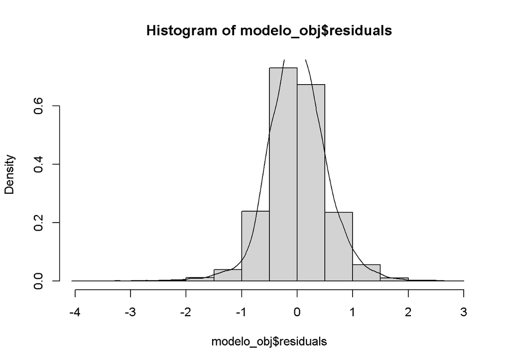

```r
hist(modelo_obj$residuals, prob = TRUE)
lines(density(modelo_obj$residuals))
```

Gráficas

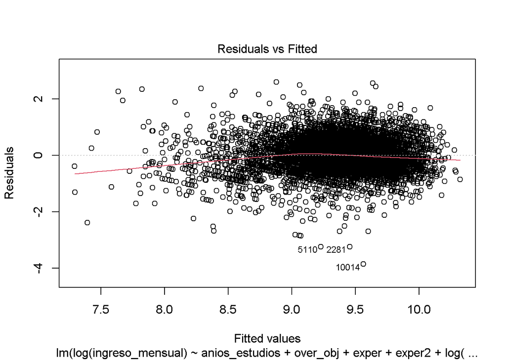

```r
plot(modelo_obj, 1)
```

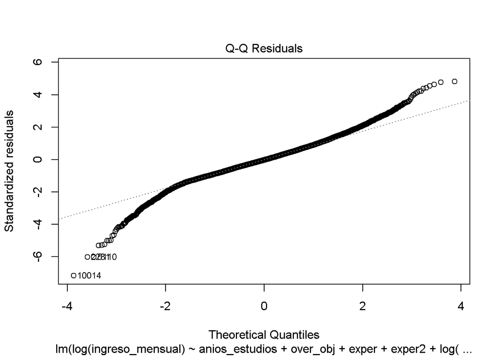

```r
plot(modelo_obj, 2)
```

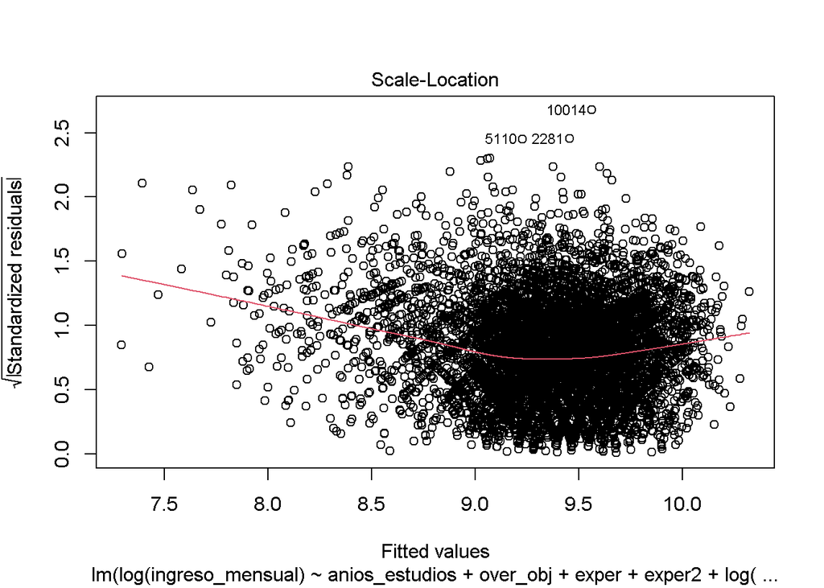

```r
plot(modelo_obj, 3)
```

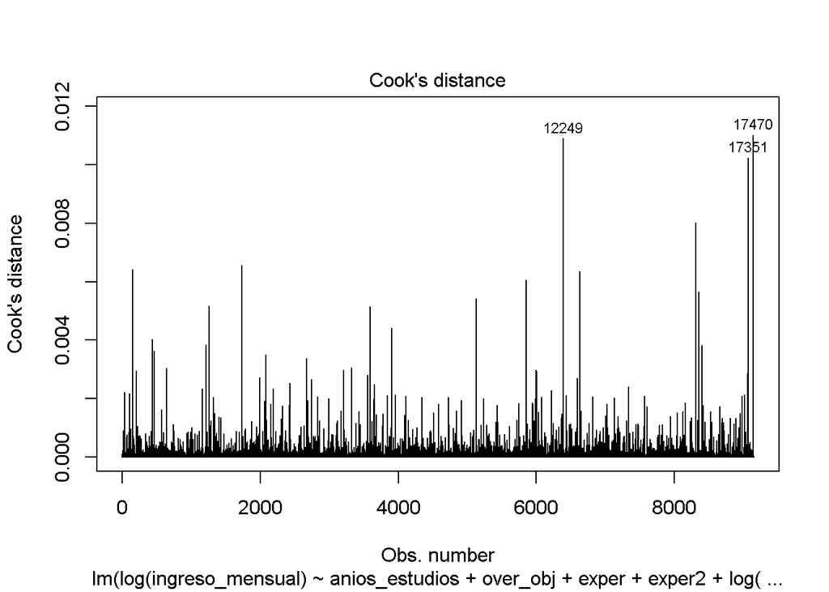

```r
plot(modelo_obj, 4)
```

Pruebas estadísticas

```r
# normalidad
moments::jarque.test(resid(modelo_obj)) # se rechaza H0
```

```
##
##  Jarque-Bera Normality Test
##
## data:  resid(modelo_obj)
## JB = 2062.6, p-value < 2.2e-16
## alternative hypothesis: greater
```

```r
nortest::ad.test(resid(modelo_obj)) # se rechaza H0
```

```
##
##  Anderson-Darling normality test
##
## data:  resid(modelo_obj)
## A = 27.563, p-value < 2.2e-16
```

```r
# homocedasticidad
lmtest::bptest(modelo_obj) # se rechaza H0
```

```
##
##  studentized Breusch-Pagan test
##
## data:  modelo_obj
## BP = 347.79, df = 15, p-value < 2.2e-16
```

```r
# autocorrelación
lmtest::dwtest(modelo_obj) # no se rechaza H0
```

```
##
##  Durbin-Watson test
##
## data:  modelo_obj
## DW = 1.9904, p-value = 0.3235
## alternative hypothesis: true autocorrelation is greater than 0
```

# Dudas

¿Distribución agregada de las ocupaciones y trabajadores por nivel educativo?

```r
ocupada %>%
  count(ocupacion1) %>%
  mutate(prop = n / sum(n) * 100)
```

```
## # A tibble: 9 × 3
##   ocupacion1     n  prop
##   <chr>      <int> <dbl>
## 1 1           6518  3.42
## 2 2          35436 18.6
## 3 3          14184  7.44
## 4 4          26451 13.9
## 5 5          18353  9.62
## 6 6           9692  5.08
## 7 7          20514 10.8
## 8 8          22271 11.7
## 9 9          37268 19.5
```

En el caso de trabajadores

```r
ocupada %>%
  count(escolaridad) %>%
  mutate(prop = n / sum(n) * 100)
```

```
## # A tibble: 11 × 3
##    escolaridad     n    prop
##          <int> <int>   <dbl>
##  1           0  4286  2.25
##  2           1    84  0.0441
##  3           2 29078 15.2
##  4           3 51824 27.2
##  5           4 46621 24.4
##  6           5   216  0.113
##  7           6  5425  2.84
##  8           7 47952 25.1
##  9           8  4171  2.19
## 10           9   667  0.350
## 11          NA   363  0.190
```

El 42% de personas reportan tener estudios básicos (primaria 15% y secundaria 27%), seguido de 24% de nivel medio superior, y 31% de nivel superior donde el 25% se concentra en licenciatura.

Al comparar, se observa que el 22% de las ocupaciones requieren educación superior mientras que el 31% de los trabajadores reportan dicho nivel educativo.

```r
# ocupaciones
x1 <- ocupada %>%
  count(ocupacion1) %>%
  mutate(
    prop = n / sum(n) * 100,
    ocupacion1 = as.integer(ocupacion1),
    ocupaciones = case_when(
      between(ocupacion1, 1, 2) ~ 1,
      between(ocupacion1, 3, 8) ~ 2,
      TRUE ~ 3
    )
  ) %>%
  group_by(ocupaciones) %>%
  summarise(ocup = sum(prop))

# trabajadores
x2 <- ocupada %>%
  count(escolaridad) %>%
  mutate(
    prop = n / sum(n) * 100,
    trabajadores = case_when(
      between(escolaridad, 5, 9) ~ 1,
      between(escolaridad, 3, 4) ~ 2,
      escolaridad == 2 ~ 3,
      TRUE ~ NA
    )
  ) %>%
  group_by(trabajadores) %>%
  summarise(trab = sum(prop))

x1 %>% left_join(x2, by = c("ocupaciones" = "trabajadores")) %>%
  mutate(
    desajuste = if_else(ocup < trab, "sobre-oferta", "sobre-demanda")
  )
```

```
## # A tibble: 3 × 4
##   ocupaciones  ocup  trab desajuste
##         <dbl> <dbl> <dbl> <chr>
## 1           1  22.0  30.6 sobre-oferta
## 2           2  58.5  51.6 sobre-demanda
## 3           3  19.5  15.2 sobre-demanda
```

Se observa que, del total de trabajadores, el 31% reportan estudios de nivel superior mientras que sólo hay un 22% de ocupaciones (del total de ocupaciones) lo que evidencia una sobre-oferta de profesionistas, es decir, hay más trabajadores que ocupaciones en tal nivel educativo. ¿Han crecido más las ocupaciones con dicho nivel o los que requieren educación básica?